# Data Exploration and Feature Engineering

## Initialize Environment

```r
library("tidyverse") # Data munging functions
library("zoo")   # Feature engineering rolling aggregates
```

## Data Sources

The data for this example comes from 4 different sources which are: real-time telemetry data collected from machines, error messages, and historical maintenance records that include failures and machine information such as type and age.

### Telemetry

The first data source is the telemetry time-series data which consists of voltage, rotation, pressure and vibration measurements collected from 100 machines in real time averaged over every hour collected during the year 2015. Below, we provide first 10 records of the first machine with machineID=1. A summary of the whole dataset is also provided.

```r
telemetry <- read_csv("../Data/telemetry.csv")
# format datetime field which comes in as.character
telemetry$datetime <- as.POSIXct(telemetry$datetime,
                                 format="%m/%d/%Y %I:%M:%S %p",
                                 tz="UTC")
cat("Total Number of telemetry records:", nrow(telemetry))
```

```
Total Number of telemetry records: 876100
```

```r
range(telemetry$datetime)
```

```
[1] "2015-01-01 06:00:00 UTC" "2016-01-01 06:00:00 UTC"
```

```r
head(telemetry,10)
```

| datetime | machineID | volt | rotate | pressure | vibration |
| --- | --- | --- | --- | --- | --- |
| 2015-01-01 06:00:00 | 1 | 176.2179 | 418.5041 | 113.07794 | 45.08769 |
| 2015-01-01 07:00:00 | 1 | 162.8792 | 402.7475 | 95.46053 | 43.41397 |
| 2015-01-01 08:00:00 | 1 | 170.9899 | 527.3498 | 75.23790 | 34.17885 |
| 2015-01-01 09:00:00 | 1 | 162.4628 | 346.1493 | 109.24856 | 41.12214 |
| 2015-01-01 10:00:00 | 1 | 157.6100 | 435.3769 | 111.88665 | 25.99051 |
| 2015-01-01 11:00:00 | 1 | 172.5048 | 430.3234 | 95.92704 | 35.65502 |
| 2015-01-01 12:00:00 | 1 | 156.5560 | 499.0716 | 111.75568 | 42.75392 |
| 2015-01-01 13:00:00 | 1 | 172.5228 | 409.6247 | 101.00108 | 35.48201 |
| 2015-01-01 14:00:00 | 1 | 175.3245 | 398.6488 | 110.62436 | 45.48229 |
| 2015-01-01 15:00:00 | 1 | 169.2184 | 460.8507 | 104.84823 | 39.90174 |

```r
tail(telemetry,10)
```

| datetime | machineID | volt | rotate | pressure | vibration |
| --- | --- | --- | --- | --- | --- |
| 2015-12-31 21:00:00 | 100 | 153.4046 | 552.0126 | 99.13295 | 37.66681 |
| 2015-12-31 22:00:00 | 100 | 169.3973 | 546.1446 | 107.60703 | 38.69560 |
| 2015-12-31 23:00:00 | 100 | 152.1820 | 414.0116 | 117.42634 | 43.96671 |
| 2016-01-01 00:00:00 | 100 | 168.7400 | 439.4841 | 103.15823 | 47.28900 |
| 2016-01-01 01:00:00 | 100 | 162.7427 | 481.2539 | 101.58973 | 44.38275 |
| 2016-01-01 02:00:00 | 100 | 179.4382 | 395.2228 | 102.29071 | 50.77194 |
| 2016-01-01 03:00:00 | 100 | 189.6176 | 446.2080 | 98.18061 | 35.12307 |
| 2016-01-01 04:00:00 | 100 | 192.4834 | 447.8165 | 94.13284 | 48.31456 |
| 2016-01-01 05:00:00 | 100 | 165.4753 | 413.7717 | 104.08107 | 44.83526 |
| 2016-01-01 06:00:00 | 100 | 171.3360 | 496.0969 | 79.09554 | 37.84525 |

```r
summary(telemetry)
```

```
    datetime                     machineID           volt            rotate         pressure        vibration
 Min.   :2015-01-01 06:00:00   Min.   :  1.00   Min.   : 97.33   Min.   :138.4   Min.   : 51.24   Min.   :14.88
 1st Qu.:2015-04-02 12:00:00   1st Qu.: 25.75   1st Qu.:160.30   1st Qu.:412.3   1st Qu.: 93.50   1st Qu.:36.78
 Median :2015-07-02 18:00:00   Median : 50.50   Median :170.61   Median :447.6   Median :100.43   Median :40.24
 Mean   :2015-07-02 18:00:00   Mean   : 50.50   Mean   :170.78   Mean   :446.6   Mean   :100.86   Mean   :40.39
 3rd Qu.:2015-10-02 00:00:00   3rd Qu.: 75.25   3rd Qu.:181.00   3rd Qu.:482.2   3rd Qu.:107.56   3rd Qu.:43.78
 Max.   :2016-01-01 06:00:00   Max.   :100.00   Max.   :255.12   Max.   :695.0   Max.   :185.95   Max.   :76.79
```

As an example, below is a plot of voltage values for two machineIDs for January 2015.

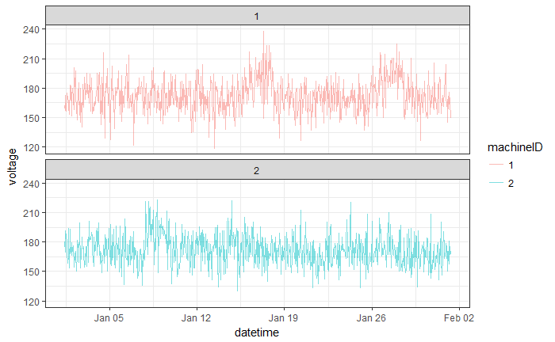

```r
theme_set(theme_bw())  # theme for figures
options(repr.plot.width = 8, repr.plot.height = 6)
ggplot(data = telemetry %>% filter(machineID %in% 1:2,
                                 datetime > as.POSIXct("2015-01-01"),
                                 datetime < as.POSIXct("2015-02-01")),
       aes(x = datetime, y = volt, col = factor(machineID))) +
  geom_line(alpha = 0.5) +
  labs(y = "voltage", color = "machineID") +
  facet_wrap(~machineID, ncol=1)
```

### Errors

The second major data source is the error logs. These are non-breaking errors thrown while the machine is still operational and do not constitute as failures. The error date and times are rounded to the closest hour since the telemetry data is collected at an hourly rate.

```r
# download errors dataset
errors <- read_csv("../Data/errors.csv")
# format datetime and errorID fields
errors$datetime <- as.POSIXct(errors$datetime,
                              format="%m/%d/%Y %I:%M:%S %p",
                              tz="UTC")
errors$errorID <- as.factor(errors$errorID)
cat("Total Number of error records:",nrow(errors))
```

```
Total Number of error records: 3919
```

```r
errors[c(1:5, nrow(errors)-4:1),]
```

| datetime | machineID | errorID |
| --- | --- | --- |
| 2015-01-03 07:00:00 | 1 | error1 |
| 2015-01-03 20:00:00 | 1 | error3 |
| 2015-01-04 06:00:00 | 1 | error5 |
| 2015-01-10 15:00:00 | 1 | error4 |
| 2015-01-22 10:00:00 | 1 | error4 |
| 2015-11-21 08:00:00 | 100 | error2 |
| 2015-12-04 02:00:00 | 100 | error1 |
| 2015-12-08 06:00:00 | 100 | error2 |
| 2015-12-08 06:00:00 | 100 | error3 |

```
Ignoring unknown parameters: binwidth, bins, pad
```

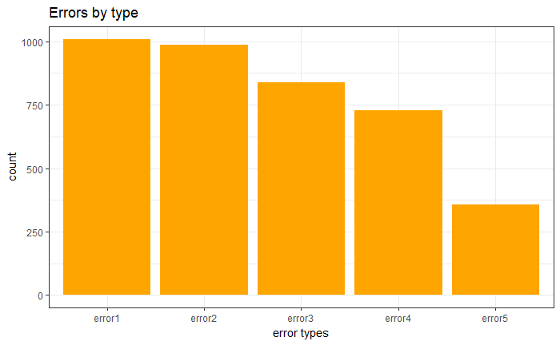

```r
options(repr.plot.width = 5, repr.plot.height = 3)
ggplot(errors, aes(x = errorID)) +
    geom_histogram(fill = "orange", stat="count") +
    labs(title = "Errors by type", x = "error types")
```

```
Ignoring unknown parameters: binwidth, bins, pad
```

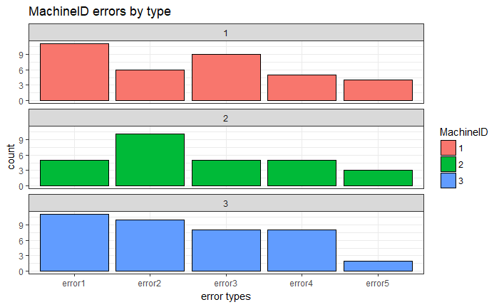

```r
options(repr.plot.width = 6, repr.plot.height = 5)
ggplot(errors %>% filter(machineID < 4),
       aes(x = errorID, fill = factor(machineID))) +
    geom_histogram(color = "black", stat="count") +
    labs(title = "MachineID errors by type", x = "error types", fill="MachineID")+
    facet_wrap(~machineID, ncol = 1)
```

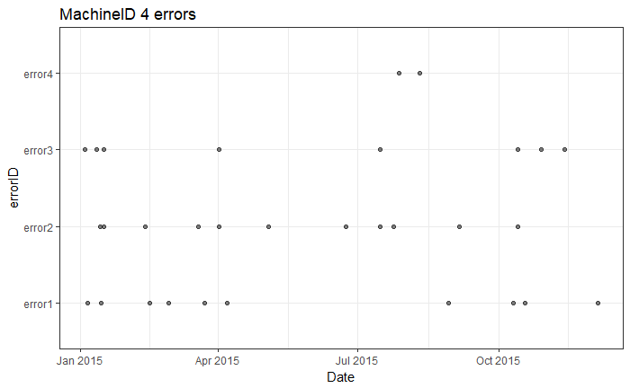

```r
options(repr.plot.width = 7, repr.plot.height = 5)
ggplot(errors %>% filter(machineID == 4),
       aes(y = errorID, x = datetime)) +
    geom_point(color = "black", alpha = 0.5) +
    labs(title = "MachineID 4 errors", x = "Date")
```